# Final Project-Machine Learning Course

Maliheh Shomali

February 21, 2018

## Model Used

The exacted outcome variable is **classe**, a 5 level of factor variable. In this dataset, participants were asked to perform one set of 10 repetitions of the Unilateral Dumbbell Biceps Curl in 5 different fashion:

Class A: exactly according to the specification

Class B: throwing the elbows to the front

Class c: lifting the dumbbell only halfway

Class D: lowering the dumbbell only halfway

Class E: throwing the hips to the front.

Class A correspond to the specified execution of the exercise, while the other 4 classes correspond to common mistakes.

## Data

The training data for this project are available here: https://d396qusza40orc.cloudfront.net/predmachlearn/pml-training.csv

The test data are available here: https://d396qusza40orc.cloudfront.net/predmachlearn/pml-testing.csv

The data for this project come from this source: http://web.archive.org/web/20161224072740/http:/groupware.les.inf.puc-rio.br/har.

### Lodaing libraries

```r
library(rpart.plot)
library(lattice)
library(ggplot2)
library(caret)
library(rpart)
library(randomForest)
```

### Data Analysis

Loading the data form the provided link and identifying the missing data (NA, " “, and #DIV/0) and labeling them as”NA“.

```r
# Download the dataset
url.train <- "https://d396qusza40orc.cloudfront.net/predmachlearn/pml-training.csv"
url.test <- "https://d396qusza40orc.cloudfront.net/predmachlearn/pml-testing.csv"

# Load the training and test sets
training_set <- read.csv(url(url.train), na.strings = c("NA", "", "#DIV0!"))
testing_set <- read.csv(url(url.test), na.strings = c("NA", "", "#DIV0!"))

# Exploring the data
dim(training_set)
```

```
## [1] 19622   160
```

```r
dim(testing_set)
```

```
## [1]  20 160
```

```r
table (training_set$classe)
```

```
##
##    A    B    C    D    E
## 5580 3797 3422 3216 3607
```

```r
head(colnames(training_set))
```

```
## [1] "X"                    "user_name"            "raw_timestamp_part_1"
## [4] "raw_timestamp_part_2" "cvtd_timestamp"       "new_window"
```

```r
tail(colnames(training_set))
```

```
## [1] "accel_forearm_y"  "accel_forearm_z"  "magnet_forearm_x"
## [4] "magnet_forearm_y" "magnet_forearm_z" "classe"
```

```r
# Removing all variables containing NA values
training_set <- training_set[, colSums(is.na(training_set)) == 0]
testing_set <- testing_set[, colSums(is.na(testing_set)) == 0]


# Removing the varibales that are irrelevent to the prediction (column 1 to 7)
training_set <- training_set[, -c(1:7)]
testing_set <- testing_set[, -c(1:7)]

# Excluding the "classe" in training dataset.
training_set$classe <- factor(training_set$classe)

# Partitioning the dataset into training (60%), testing (20%) and validation part (20%).
set.seed(1235)
training_partition<- createDataPartition(y = training_set$classe, p = 0.7, list = F)
training_dataset <- training_set[training_partition,]
testing_dataset <- training_set[-training_partition,]


dim(training_dataset)
```

```
## [1] 13737    53
```

```r
dim(testing_dataset)
```

```
## [1] 5885   53
```

### Prediction by decision tree model

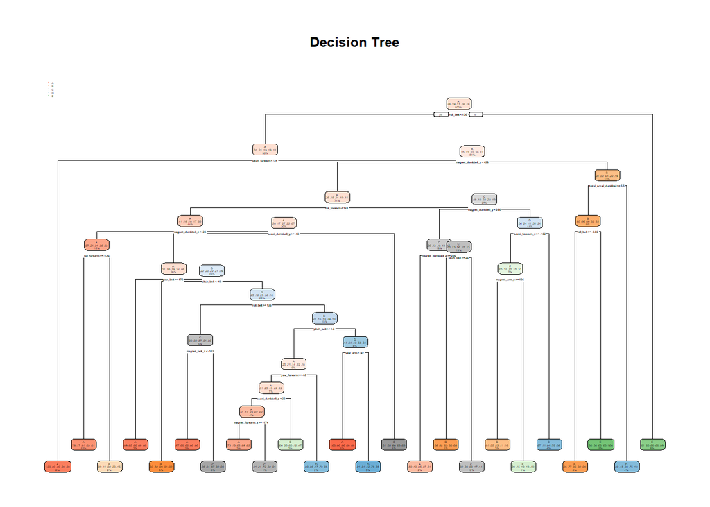

```r
decision_tree_model <- rpart(classe ~ ., data = training_dataset, method = "class")

decision_tree_prediction <- predict(decision_tree_model, testing_dataset, type = "class")

# Plot Decision Tree
rpart.plot(decision_tree_model, main = "Decision Tree")
```

```r
# Confusion matrix to test the results
confusionMatrix(decision_tree_prediction, testing_dataset$classe)
```

```
## Confusion Matrix and Statistics
##
##           Reference
## Prediction    A    B    C    D    E
##          A 1528  190   24   66   32
##          B   65  650   97   85   96
##          C   35  108  808  138   97
##          D   17   90   64  614   62
##          E   29  101   33   61  795
##
## Overall Statistics
##
##                Accuracy : 0.7468
##                  95% CI : (0.7355, 0.7579)
##     No Information Rate : 0.2845
##     P-Value [Acc > NIR] : < 2.2e-16
##
##                   Kappa : 0.6786
##  Mcnemar's Test P-Value : < 2.2e-16
##
## Statistics by Class:
##
##                      Class: A Class: B Class: C Class: D Class: E
## Sensitivity            0.9128   0.5707   0.7875   0.6369   0.7348
## Specificity            0.9259   0.9277   0.9222   0.9527   0.9534
## Pos Pred Value         0.8304   0.6546   0.6813   0.7249   0.7802
## Neg Pred Value         0.9639   0.9000   0.9536   0.9305   0.9410
## Prevalence             0.2845   0.1935   0.1743   0.1638   0.1839
## Detection Rate         0.2596   0.1105   0.1373   0.1043   0.1351
## Detection Prevalence   0.3127   0.1687   0.2015   0.1439   0.1732
## Balanced Accuracy      0.9193   0.7492   0.8549   0.7948   0.8441
```

### Prediction by random forest model

```r
random_forest_model <- randomForest(classe ~. , data = training_dataset, method = "class")
random_forest_prediction <- predict(random_forest_model, testing_dataset, type = "class")

confusionMatrix(random_forest_prediction, testing_dataset$classe)
```

```
## Confusion Matrix and Statistics
##
##           Reference
## Prediction    A    B    C    D    E
##          A 1674    5    0    0    0
##          B    0 1133    4    0    0
##          C    0    1 1017   10    2
##          D    0    0    5  953    1
##          E    0    0    0    1 1079
##
## Overall Statistics
##
##                Accuracy : 0.9951
##                  95% CI : (0.9929, 0.9967)
##     No Information Rate : 0.2845
##     P-Value [Acc > NIR] : < 2.2e-16
##
##                   Kappa : 0.9938
##  Mcnemar's Test P-Value : NA
##
## Statistics by Class:
##
##                      Class: A Class: B Class: C Class: D Class: E
## Sensitivity            1.0000   0.9947   0.9912   0.9886   0.9972
## Specificity            0.9988   0.9992   0.9973   0.9988   0.9998
## Pos Pred Value         0.9970   0.9965   0.9874   0.9937   0.9991
## Neg Pred Value         1.0000   0.9987   0.9981   0.9978   0.9994
## Prevalence             0.2845   0.1935   0.1743   0.1638   0.1839
## Detection Rate         0.2845   0.1925   0.1728   0.1619   0.1833
## Detection Prevalence   0.2853   0.1932   0.1750   0.1630   0.1835
## Balanced Accuracy      0.9994   0.9969   0.9943   0.9937   0.9985
```

## Conclusion

Based on the result, the random forest model is chosen for the prediction, since the accuracy of random forest model (0.9951) is higher than of the decision tree model (0.7468).